# GF_raw_outliers_detection_new_var

```r
for(i in 1:5){
  data_name <- paste0("Run",i)

  data <- get(data_name)

   #top 1%
 outliers_top1perc_GF <- data[,c(1,15)] %>%
  arrange(pval_totalR2) %>%
slice(1:(0.01*8616)) %>%  #slice(1:(0.01*nrow(.)))
  as.data.frame()

 assign(paste0("Run",i,"_top1SNP"),outliers_top1perc_GF)

   #top 5%
 outliers_top5perc_GF <- data[,c(1,15)] %>%
  arrange(pval_totalR2) %>%
slice(1:(0.05*nrow(data))) %>%  #slice(1:(0.01*nrow(.)))
  as.data.frame()

 assign(paste0("Run",i,"_top5SNP"),outliers_top5perc_GF)

 #pvalues < 0.05
outliers_pv05 <- data[,c(1,15)] %>% filter(pval_totalR2<0.05) %>% pull(SNP)

 assign(paste0("Run",i,"_outliers_pv0.05"),outliers_pv05)

#pvalues < 0.01
outliers_pv0.01 <- data[,c(1,15)] %>% filter(pval_totalR2<0.01) %>% pull(SNP)

 assign(paste0("Run",i,"_outliers_pv0.01"),outliers_pv0.01)
}
```

One important step is to compare the results of the different runs for each threshold. We realized venn_diagram plots to visualize the number of common candidates across runs

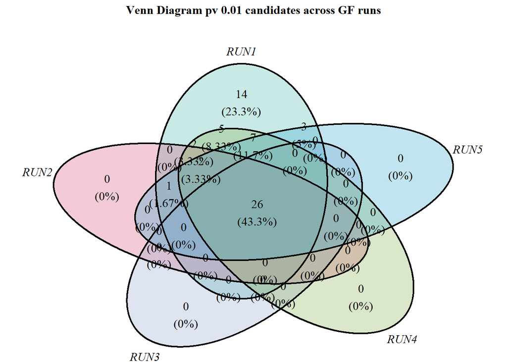

```r
#candidates 0.01
grid.newpage()
ven <- venn.diagram(x = list(Run1_outliers_pv0.01, Run2_outliers_pv0.01, Run3_outliers_pv0.01, Run4_outliers_pv0.01, Run5_outliers_pv0.01),
        category.names = c("RUN1" , "RUN2 ","RUN3","RUN4","RUN5"),
        filename = NULL,fill = c("#45B6AA","#D45176","#91A6CE","#86AD4C","#33A5CE"),
alpha = 0.30,print.mode=c("raw","percent"),margin = 0.1,  # Adjust the margins
                    cat.fontface = "italic",  # Optional: Make category names italic
                    cat.fontsize = 16,
                    main= "Venn Diagram pv 0.01 candidates across GF runs",
                    main.fontface = "bold")  # Optional: Adjust font size)
grid.draw(ven)
```

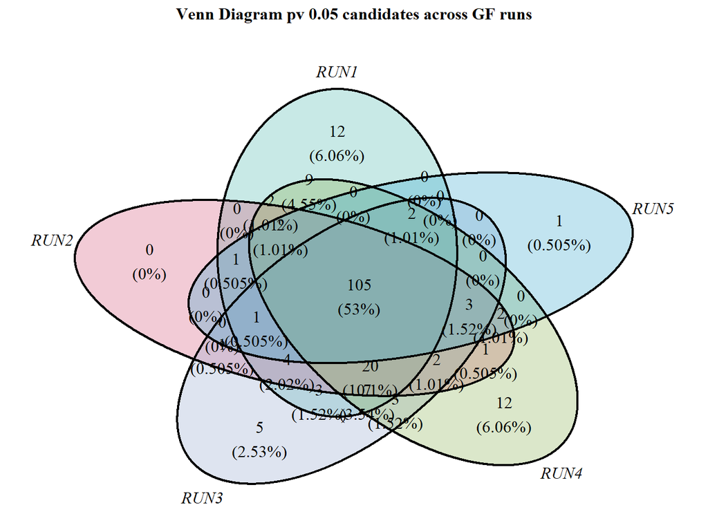

```r
#candidates 0.05
grid.newpage()
ven <- venn.diagram(x = list(Run1_outliers_pv0.05, Run2_outliers_pv0.05, Run3_outliers_pv0.05, Run4_outliers_pv0.05, Run5_outliers_pv0.05),
        category.names = c("RUN1" , "RUN2 ","RUN3","RUN4","RUN5"),
        filename = NULL,fill = c("#45B6AA","#D45176","#91A6CE","#86AD4C","#33A5CE"),
alpha = 0.30,print.mode=c("raw","percent"),margin = 0.1,  # Adjust the margins
                    cat.fontface = "italic",  # Optional: Make category names italic
                    cat.fontsize = 16,
                    main= "Venn Diagram pv 0.05 candidates across GF runs",
                    main.fontface = "bold")  # Optional: Adjust font size)
grid.draw(ven)
```

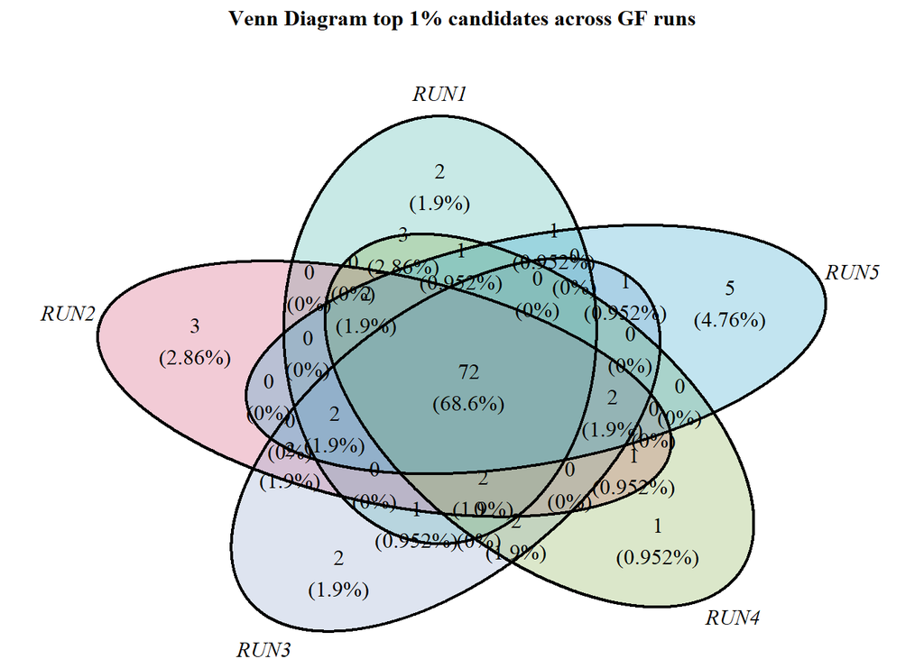

```r
#top 1%
grid.newpage()
ven <- venn.diagram(x = list(Run1_top1SNP[,1], Run2_top1SNP[,1], Run3_top1SNP[,1], Run4_top1SNP[,1], Run5_top1SNP[,1]),
        category.names = c("RUN1" , "RUN2 ","RUN3","RUN4","RUN5"),
        filename = NULL,fill = c("#45B6AA","#D45176","#91A6CE","#86AD4C","#33A5CE"),
alpha = 0.30,print.mode=c("raw","percent"),margin = 0.1,  # Adjust the margins
                    cat.fontface = "italic",  # Optional: Make category names italic
                    cat.fontsize = 16,
                    main= "Venn Diagram top 1% candidates across GF runs",
                    main.fontface = "bold")  # Optional: Adjust font size)
grid.draw(ven)
```

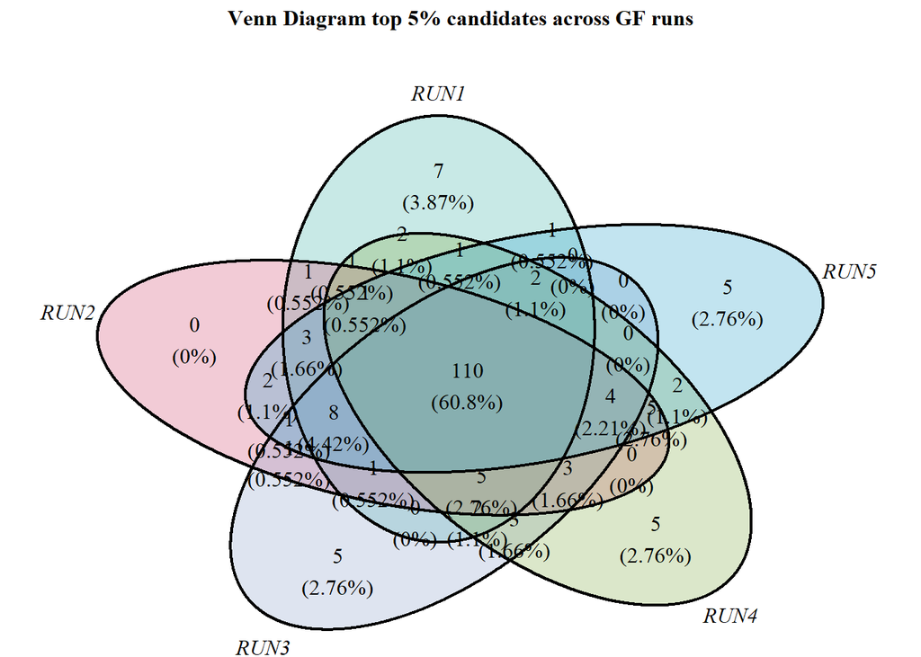

```r
#top 5%
grid.newpage()
ven <- venn.diagram(x = list(Run1_top5SNP[,1], Run2_top5SNP[,1], Run3_top5SNP[,1],Run4_top5SNP[,1], Run5_top5SNP[,1]),
        category.names = c("RUN1" , "RUN2 ","RUN3","RUN4","RUN5"),
        filename = NULL,fill = c("#45B6AA","#D45176","#91A6CE","#86AD4C","#33A5CE"),
alpha = 0.30,print.mode=c("raw","percent"),margin = 0.1,  # Adjust the margins
                    cat.fontface = "italic",  # Optional: Make category names italic
                    cat.fontsize = 16,
                    main= "Venn Diagram top 5% candidates across GF runs",
                    main.fontface = "bold")  # Optional: Adjust font size)
grid.draw(ven)
```

Globally, we can see that only a part of all the snps identified as candidates are common across runs. We can also see that the top candidates seems to be a more suitable method than using empirical pvalues (empirical pvalues are less robust than pvalues) As candidates, we selected and save the top candidates :

```
    - 1% of SNPs for downstream analysis
```

```r
#Select only the candidates identified in all 5 runs
outliers_rank_based_top1perc_GF_raw <- Reduce(intersect, list(Run1_top1SNP[,1],Run2_top1SNP[,1],Run3_top1SNP[,1],Run4_top1SNP[,1], Run5_top1SNP[,1]))

#number of outliers
length(outliers_rank_based_top1perc_GF_raw)
```

```
## [1] 72
```

```
  - 5% of SNPs for downstream analysis as a relax threshold candidates
```

```r
#Select only the outliers identified in all 5 runs
outliers_rank_based_top5perc_GF_raw <- Reduce(intersect, list(Run1_top5SNP[,1],Run2_top5SNP[,1],Run3_top5SNP[,1],Run4_top5SNP[,1], Run5_top5SNP[,1]))

#number of outliers
length(outliers_rank_based_top5perc_GF_raw)
```

```
## [1] 110
```